# How Does Education Evolving Play a Part in the Election?

Mubai Liu

9/30/2020

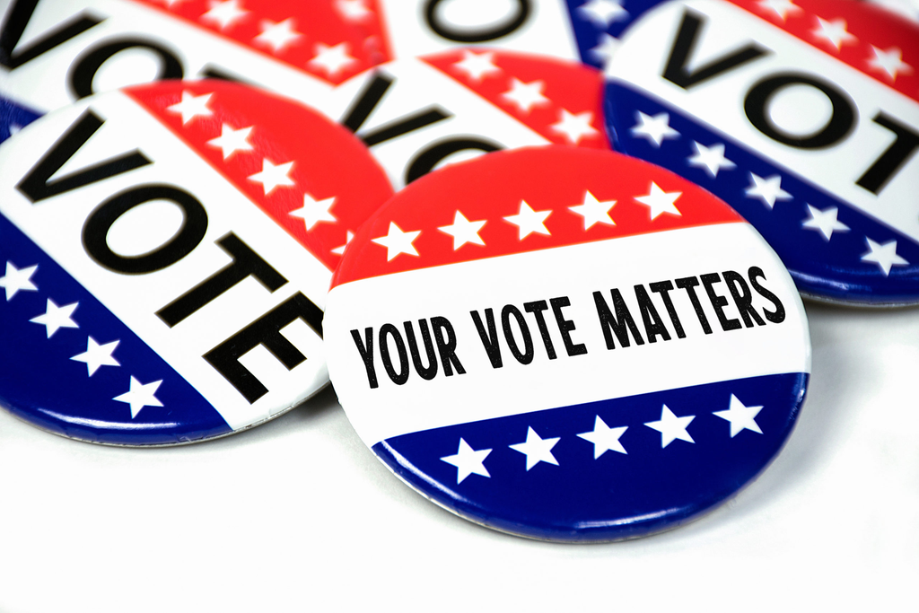

(Credit: driftwood - stock.adobe.com))

# 1. Background and Introduction

The election in America has been through almost a century, over such a long period, things changed dramatically. Take education for example, back in the year of 1948, there’s not much people who had a college degree and the system of education was not even comparable to today’s system. To partially prove my point of having a huge difference in education over such a long period, here is what I’ve found using the survey data.

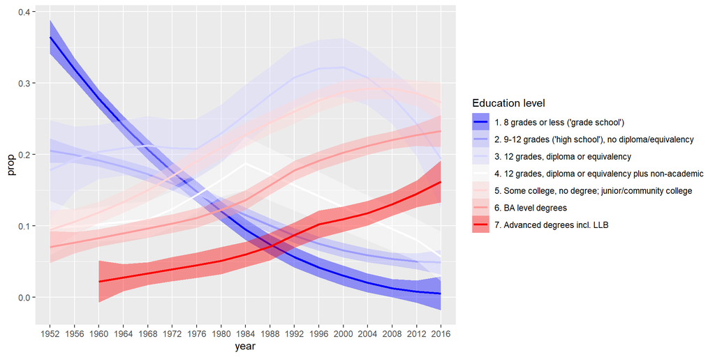

Here we can see that the Red curve increased a lot since year of 1952 whereas the blue curve went down, which at least represents that the survey’s targets are having more people with advanced degrees. Of course, the sample won’t represent the population, so the shaded area are the potential outcomes within 95% interval.

To further introduce the dataset, we are using the *American National Election Studies* (ANES)’s dataset. ANES are surveys of voters in the U.S. on the national scale. For each presidential election since 1948, ANES collects responses from respondents both before and after the election. The goal of ANES is to understand political behaviors using systematic surveys. ANES’s data and results have been routinely used by news outlets, election campaigns and political researchers.

The *Time Series Cumulative Data* of ANES include answers, from respondents from different years, on selected questions that have been asked in three or more ANES’ *Time Series* studies. Tremendous amount of efforts have been put into data consolidation as variables are often named differently in different years.

This kind of change of time could influences people so much that even the voting behavior may shift from one party to the other like we are going to discuss about in this analysis blog. For the purpose of discussion, we are mainly focus on the **White Americans** and the two main parties in America: **Democrats and Republicans**. We may answer a few questions listed below to make the purpose more clear:

**1. Is there a change of how White American’s high educated/low educated people vote for the party?**

**2. If so, what are the potential factors of such phenomenon?**

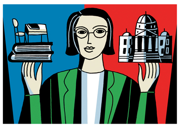

# 2. Potential Bias

Although ANES is a reliable and a credible resource of data, the potential bias inevitably exists. The first is caused by the limitation of sample size.

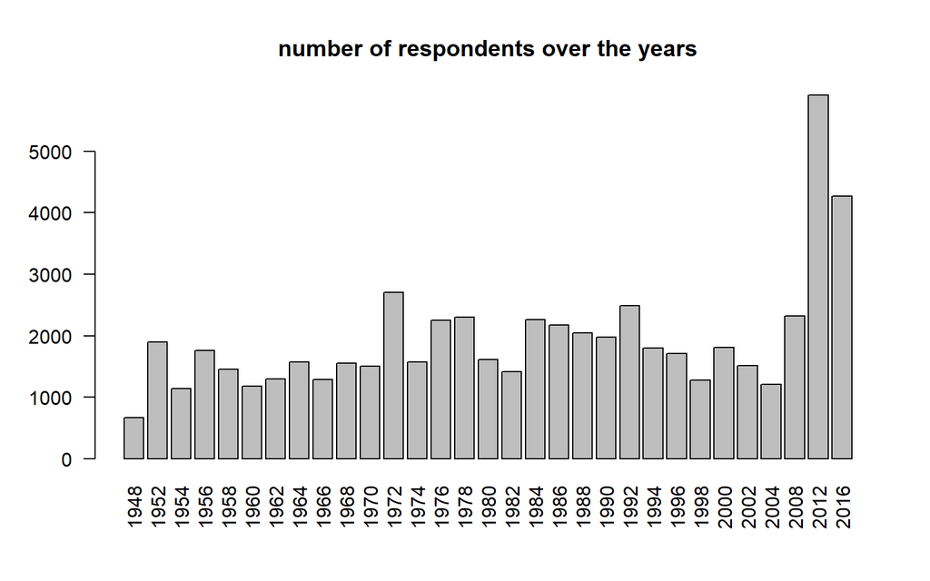

Due to some reasons with either technical or human resources issues, each voting year has a various amount of surveyed data from the lowest 662 to the highest 5914, which would cause some boost of total invested people like what happens in 2012. Therefore, we mainly use the proportion as a interests of field to discuss in this blog to eliminated the potential bias.

Another downside of the survey data is that some variables are asked nearly all the years and some are asked only a few years. This causes that each variable has at least some proportion of NA values. We can see it through the following figure by noticing how much NA values exists.

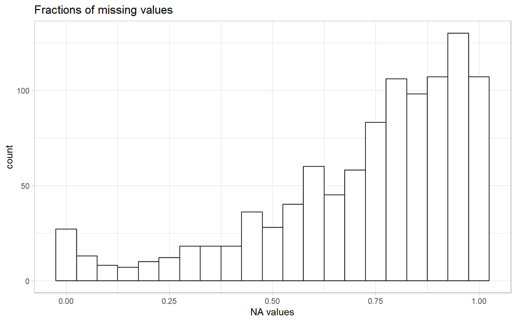

Therefore, when handling the data, we must avoid directly using the ones with NA values or otherwise it would be problematic for the visualization.

Before we touch on the actual data, let us think for a second, what variables could be useful when we are doing an analysis with education and the election? I’ll list all the variables that going to be discussed in below, and I know there could be far more factors beyond.

- Year
- Education Level
- Race
- Turnout
- Vote
- Region
- Government Spending
- Care About Who Would Win

# 3. Education Break Down

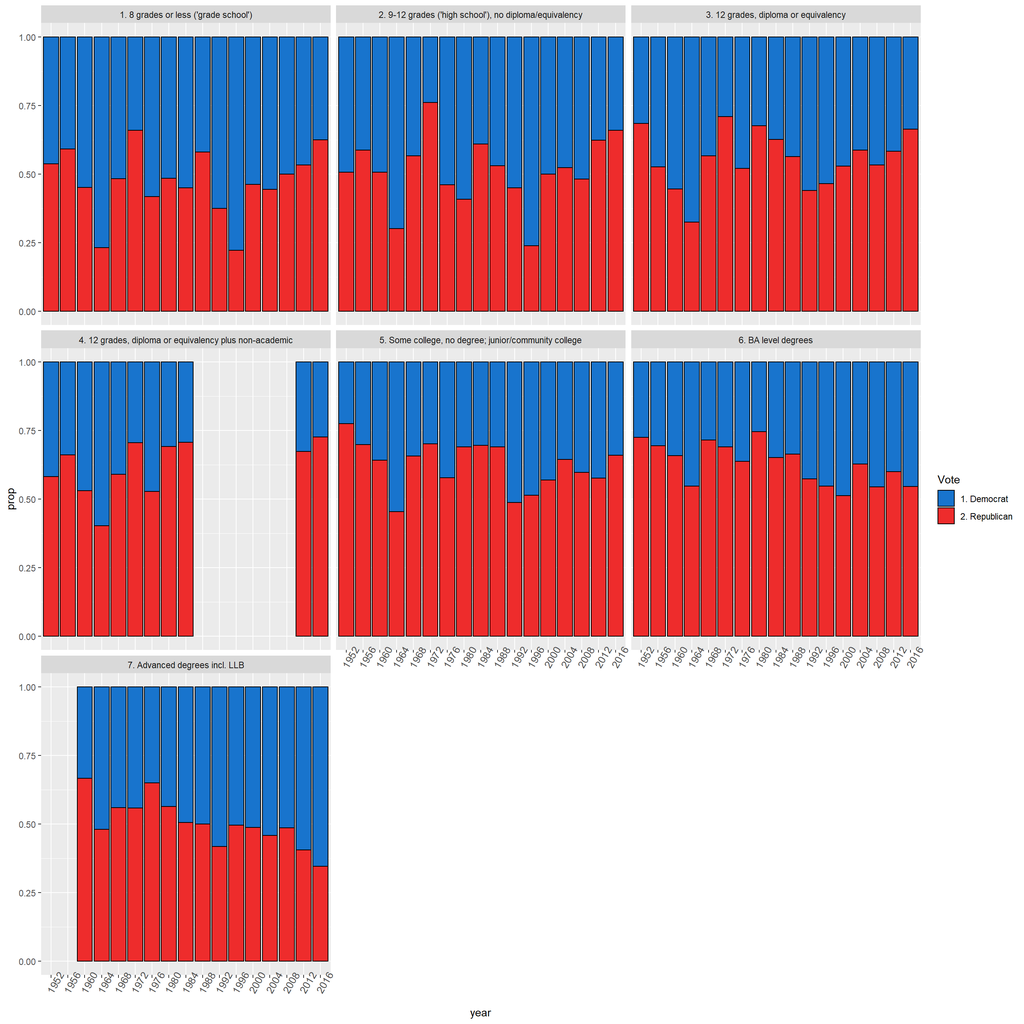

From the bar graph, we can conclude that there’s a reverse trending happening from the year of 2000. The 8 grader or less group tend to vote more for the Republicans where as the advanced degree group tend to vote more for the Democrats. Historically speaking, we can definitely see more relatively low educated people willing to vote for Democrats and those who have a diploma of college degree would rather vote Republican. So as far as the survey’s data represents, we can conclude that the first question we mentioned before is definitely a **Yes, there indeed has a change**.

Now, let’s focus more on the second question, which is what may cause such a trend.

# 4. Would Region be the Explanation?

As we all know, the geographic influences are huge for the politics in America. Each state has their own preferences when considering which political side they’ll be. Maybe a citizen who grow up in the more advanced city or a more educational resources would change how they vote? Let us examine below graphs to see the answer.

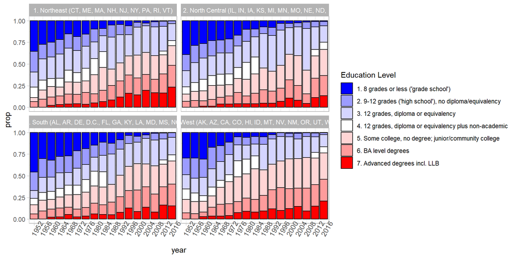

But does the geological differences really cause the shift of voting behaviors? Let’s take a more deep down look inside.

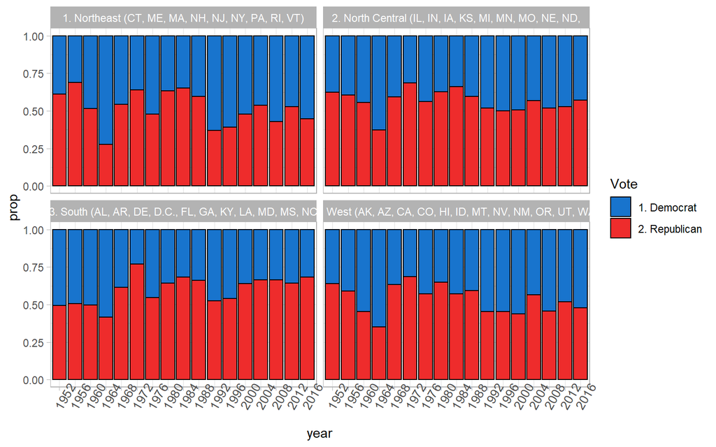

# 5. Could it be more people not willing to vote?

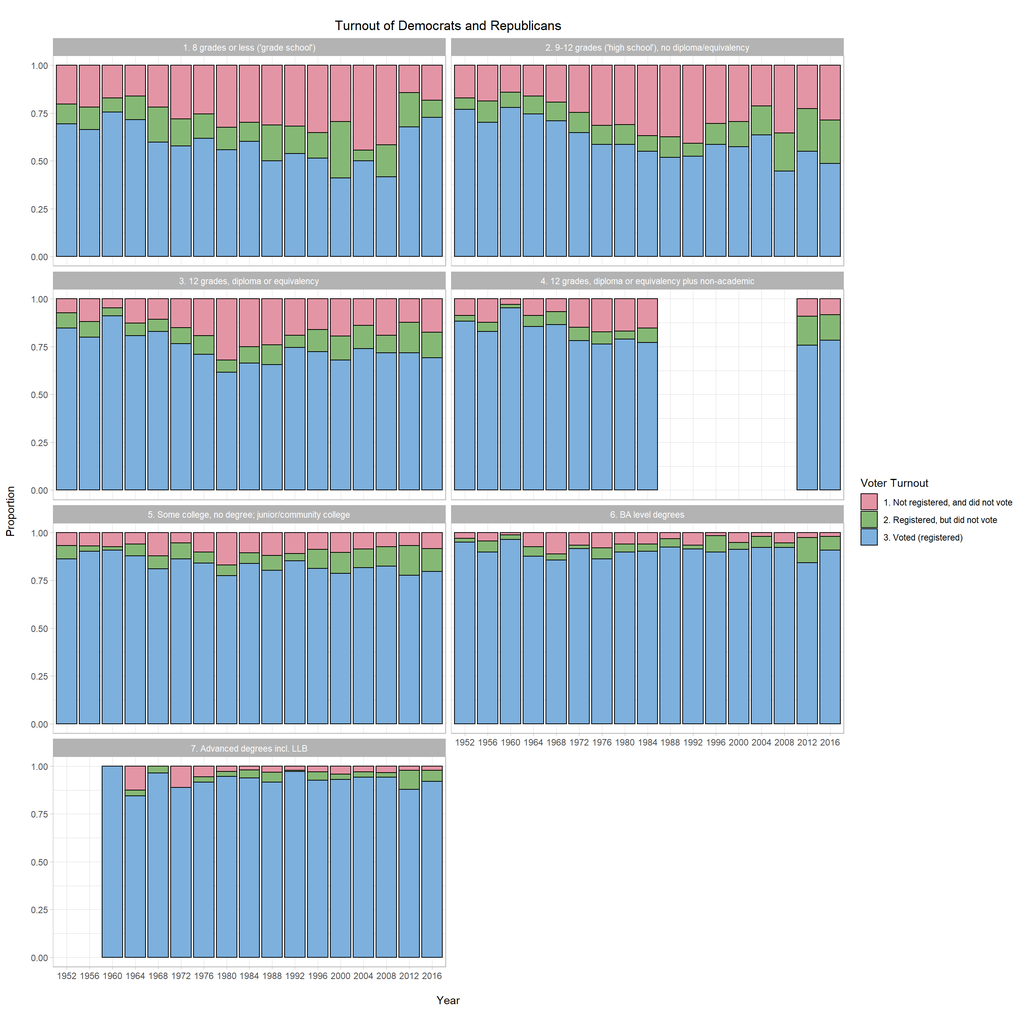

When we talk about the election, there’s at least some degree’s of people will not vote. Although above graphics can’t could the turnout rate has changed over time, but we now understand that each group of educated people may have a different voting behavior. The lower the degree, the higher chance of not voting.

# 6. What about how much spending the government willing to pay?

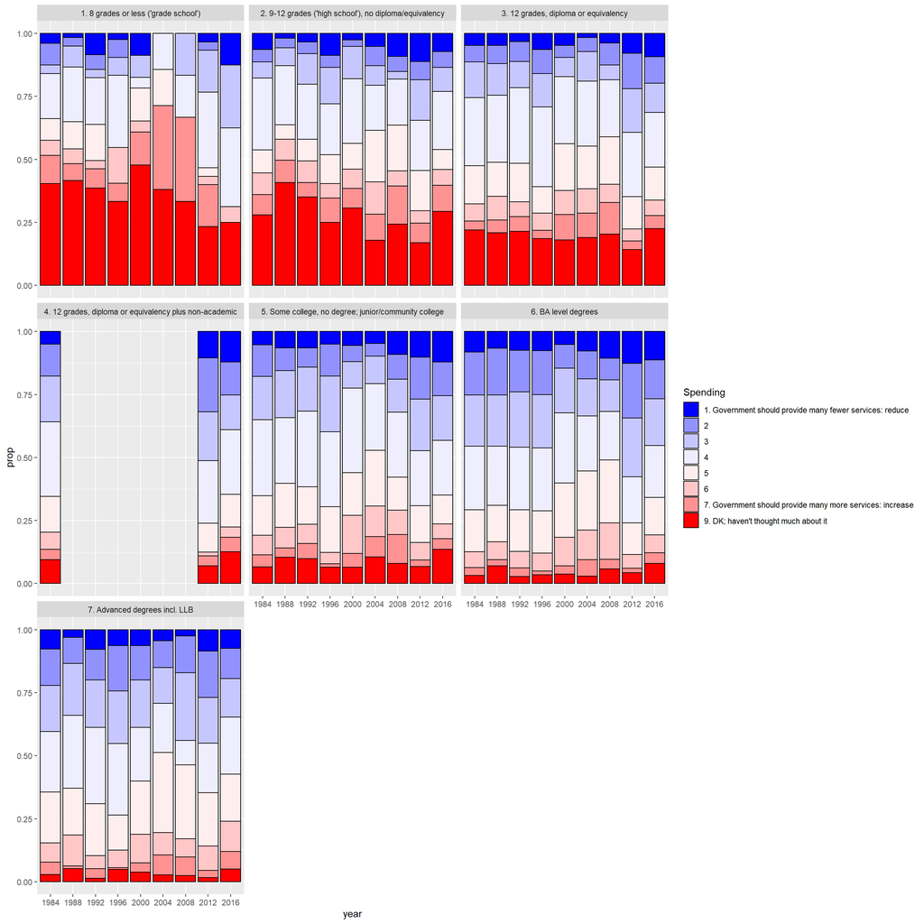

# 7. Do different educated level people really care who would win?

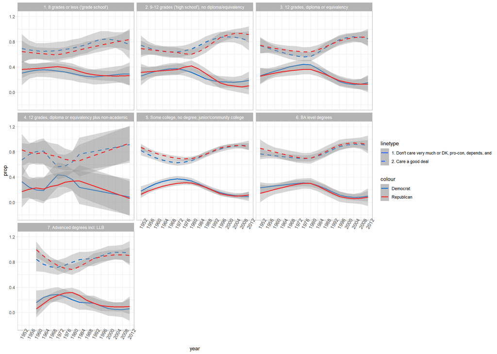

Now for the final variable that we’re going to illustrate, we check whether or not the voting is pointless after all. Because that proportion of change may happen simply cause they don’t even care which parties win, especially for the low educated ones. All the graphs above have a similar shape which tells that people indeed starts to care more on the election of who’s gonna win, which kinds of explain why for the group of 8 grades or lower people may starts to thinking differently compared to a half century before. But the rate of don’t care is still very high compared to the advanced degree group.

# 8. Conclusion

In conclusion, for the first question we’ve listed, the answer is a convincingly yes because of the proportion shifting as time goes on. But for the second question, due to the limitation of time and length of the blog, we simply can’t list all the factors (like income etc.) to discuss and draw the graph with it, even though it is highly possible to be one of the reason. However, we managed to draw a few conclusions like the geological difference may not be the reason, and the concerns about who would win and how much of the government willing to do for supporting education may be the answer of the second question.

# 9. Reflection

Like I’ve mentioned above, the more variables we use for analysis the more accurate our result will be to explain these differences in voting behavior. Note that attributes like age, gender, occupation did not seem to have any impact on our result so I choose to ignore for a second. But without even try to check the hypothesis is dangerous. I understand that there are far more space to discover such as the more quantitative analysis beyond simply drawing graphs, but for now we’re just settling down on the Exploratory part and if we have time we’ll do more like a prediction or inference on this dataset. This would be such an insteresting topic with the upcoming 2020’s election.